# Analysis Musterlösung

Author

Sandra Grinschgl, Aaron Friedli, Lars Schilling

# 1 Analysis - Statistische Reproduktion von Grinschgl et al. (2021) mit simulierten Daten

Grinschgl, S., Meyerhoff, H.S., Schwan, S. *et al.* From metacognitive beliefs to strategy selection: does fake performance feedback influence cognitive offloading?. *Psychological Research* **85**, 2654–2666 (2021). https://doi.org/10.1007/s00426-020-01435-9

Dies ist eine von mehreren möglichen Lösungen für die Analysis- und Processing-Skripte. Da die Berichte individuell an Ihren spezifischen Datensatz angepasst wurden, bedeuten Abweichungen von dieser Vorlage **nicht,** dass Ihr Code oder Ihre Ergebnisse notwendigerweise falsch sind.

**Geben Sie diese Datei nicht weiter! Sie ist nur für Studierende zugänglich, die am Seminar “R u Ready” im Herbstsemester 2025 teilnehmen.**

# 2 Vorbereitungen

### 2.0.1 Notation

```r
options(scipen = 999)
```

### 2.0.2 Libraries

```r
library(readxl)
library(tidyverse)
library(kableExtra)
library(gtsummary)
library(afex)
library(effectsize)
library(car)
library(BayesFactor)
library(lmtest)
library(relaimpo)
library(onewaytests)
library(skimr)
library(inspectdf)
library(here)
library(emmeans)
```

### 2.0.3 Laden der bereingten Daten

```r
dat_full <- read_csv(here("data/processed/dat_full.csv"))
dat_full_long <- read_csv(here("data/processed/dat_full_long.csv"))
```

### 2.0.4 Faktoren setzen

```r
dat_full$group_all <- factor(dat_full$group_all, levels = c("below", "control", "above"))

levels(dat_full$group_all)
```

```
[1] "below"   "control" "above"
```

```r
dat_full_long$time_rating <- factor(dat_full_long$time_rating, levels = c("pre_1", "pre_4"))


levels(dat_full_long$time_rating) #Check Levels of Factor
```

```
[1] "pre_1" "pre_4"
```

# 3 Analysis

## 3.1 Analyse der Simulierten Daten

### 3.1.1 Deskriptiva (Means, SDs) (Tabelle optional)

```r
dat_full_descrip <- dat_full |>
  dplyr::select(group_all, mean_rl_all, mean_e1_all, mean_d1_all, mean_d_all, cvstm_propcorrect) |>
  tbl_summary(
    by = group_all,
    statistic = all_continuous() ~ "{mean} ({sd})",
    digits = all_continuous() ~ 2,
    label = list(
      mean_rl_all = "Openings of the model window",
      mean_e1_all = "Initially correctly copied items",
      mean_d1_all = "Initial encoding duration (sec)",
      mean_d_all = "Trial duration (sec)",
      cvstm_propcorrect = "Working memory performance")
  ) |>
  modify_header(
    label = "",
    stat_1 = "Below-average group\n M (SD)",
    stat_2 = "Control-average group\n M (SD)",
    stat_3 = "Average group\n M (SD)") |>
  modify_footnote(everything() ~ NA)

dat_full_descrip
```

|  | Below-average group M (SD) | Control-average group M (SD) | Average group M (SD) |
| --- | --- | --- | --- |
| Openings of the model window | 4.89 (0.90) | 4.99 (0.75) | 5.10 (0.89) |
| Initially correctly copied items | 3.39 (0.50) | 3.39 (0.53) | 3.31 (0.54) |
| Initial encoding duration (sec) | 7.31 (3.06) | 7.90 (3.16) | 7.33 (2.39) |
| Trial duration (sec) | 41.67 (7.00) | 42.97 (7.32) | 42.75 (9.58) |
| Working memory performance | 0.75 (0.07) | 0.74 (0.06) | 0.75 (0.08) |

### 3.1.2 Subjective Performance Ratings

*“To investigate whether the participants changed their metacognitive evaluations according to the provided fake performance feedback, we performed a preregistered **mixed 2 × 3 ANOVA** with the within factor “**time of pre-rating**” (first pre-rating before receiving any feedback vs. fourth pre-rating after receiving feedback for three times) and the between factor “feedback group” (below-average vs. above-average vs. control).”*

#### 3.1.2.1 2x3 ANOVA

```r
anova_ratings <- aov_4(rating ~ group_all + (time_rating | code),
                 anova_table = list(es = c("ges", "pes")), #specify to obtain generalized and partial eta squared
                 data = dat_full_long)
```

```
Converting to factor: group_all
```

```
Contrasts set to contr.sum for the following variables: group_all
```

```r
summary(anova_ratings)
```

```
Univariate Type III Repeated-Measures ANOVA Assuming Sphericity

                      Sum Sq num Df Error SS den Df  F value
(Intercept)           835401      1    31569    156 4128.209
group_all               9848      2    31569    156   24.333
time_rating             7104      1    19716    156   56.209
group_all:time_rating   7108      2    19716    156   28.121
                                     Pr(>F)
(Intercept)           < 0.00000000000000022 ***
group_all                 0.000000000634272 ***
time_rating               0.000000000004592 ***
group_all:time_rating     0.000000000037233 ***
---
Signif. codes:  0 '***' 0.001 '**' 0.01 '*' 0.05 '.' 0.1 ' ' 1
```

```r
anova_ratings$anova_table
```

```
Anova Table (Type 3 tests)

Response: rating
                      num Df den Df    MSE      F     pes     ges
group_all                  2    156 202.36 24.333 0.23778 0.16109
time_rating                1    156 126.38 56.209 0.26487 0.12166
group_all:time_rating      2    156 126.38 28.121 0.26499 0.12173
                                 Pr(>F)
group_all             0.000000000634272 ***
time_rating           0.000000000004592 ***
group_all:time_rating 0.000000000037233 ***
---
Signif. codes:  0 '***' 0.001 '**' 0.01 '*' 0.05 '.' 0.1 ' ' 1
```

```r
eta_squared(anova_ratings, partial = FALSE) #eta squared as reported in the article
```

```
# Effect Size for ANOVA (Type III)

Parameter             | Eta2 |       95% CI
-------------------------------------------
group_all             | 0.13 | [0.05, 1.00]
time_rating           | 0.09 | [0.03, 1.00]
group_all:time_rating | 0.09 | [0.03, 1.00]

- One-sided CIs: upper bound fixed at [1.00].
```

Wir beobachteten einen signifikanten **main effect** des Faktors „**feedback group**“, $F$(2, 156) = 24.33, $p$ < .001, $\eta^2$ = 0.13, sowie einen signifikanten **main effect** des Faktors „**time of pre-rating**“, $F$(1, 156) = 56.21, $p$ < .001, $\eta^2$ = 0.09. Am wichtigsten ist jedoch, dass wir auch einen signifikanten **Interaktionseffekt** zwischen diesen Faktoren fanden, $F$(2, 156) = 28.12, $p$ < .001, $\eta^2$ = 0.09.

#### 3.1.2.2 Plot (optional)

```
Ignoring unknown labels:
• shape : "Feedback Group"
```

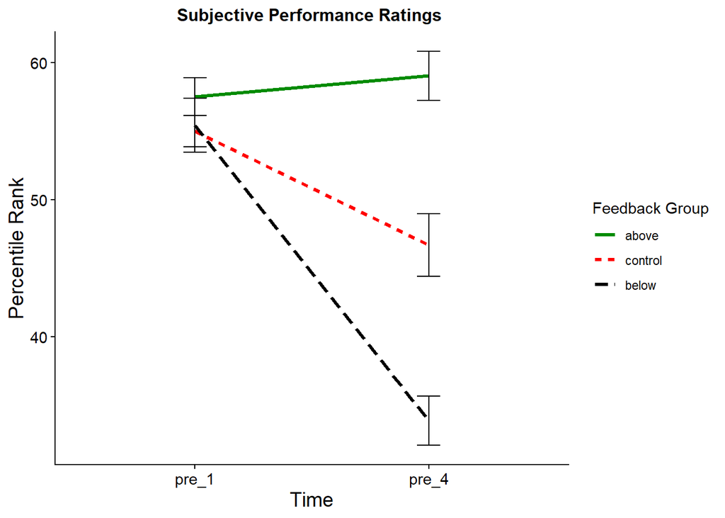

```r
descriptives <- dat_full_long |>
  group_by(group_all, time_rating) |>
  summarize(N = length(rating),
               mean_d = mean(rating),
               sd_d   = sd(rating),
               se_d   = sd_d / sqrt(N)
)
descriptives$group_all <- factor(descriptives$group_all, c("above", "control", "below"))

rate_plot <- descriptives |>
  ggplot(aes(x = time_rating,
             y = mean_d,
             group = group_all))

rate_plot +
  geom_line(aes(color = group_all, linetype = group_all), size = 1.2) +
  geom_errorbar(aes(ymin = mean_d - se_d, ymax = mean_d + se_d), width = .1) +
  scale_color_manual(values = c("green4", "red", "black")) +
  theme_classic() +
  labs(title = "Subjective Performance Ratings ") +
  ylab("Percentile Rank") +
  xlab("Time") +
  theme(plot.title = element_text(hjust = 0.5, size = 12, face = "bold"),
        axis.text = element_text(size = 11), axis.title = element_text(size = 14)) +
  labs(colour = "Feedback Group", linetype = "Feedback Group", shape = "Feedback Group")
```

#### 3.1.2.3 Post-hoc t-Tests

Entweder mit einzelnen t-tests mit Effektstärken.

```r
# Subset
aboveRating <- subset(dat_full_long, group_all == "above")
controlRating <- subset(dat_full_long, group_all == "control")
belowRating <- subset(dat_full_long, group_all == "below")

# Above-average vs. Control at Pre 1
t.test(aboveRating$rating[aboveRating$time_rating == "pre_1"], controlRating$rating[controlRating$time_rating == "pre_1"], var.equal = TRUE)
```

```
    Two Sample t-test

data:  aboveRating$rating[aboveRating$time_rating == "pre_1"] and controlRating$rating[controlRating$time_rating == "pre_1"]
t = 1.4054, df = 104, p-value = 0.1629
alternative hypothesis: true difference in means is not equal to 0
95 percent confidence interval:
 -1.031499  6.050367
sample estimates:
mean of x mean of y
 57.50943  55.00000
```

```r
effsize::cohen.d(aboveRating$rating[aboveRating$time_rating == "pre_1"], controlRating$rating[controlRating$time_rating == "pre_1"])
```

```
Cohen's d

d estimate: 0.2730021 (small)
95 percent confidence interval:
     lower      upper
-0.1140074  0.6600117
```

```r
# Above-average vs. Below-average at Pre 1
t.test(aboveRating$rating[aboveRating$time_rating == "pre_1"], belowRating$rating[belowRating$time_rating == "pre_1"], var.equal = TRUE)
```

```
    Two Sample t-test

data:  aboveRating$rating[aboveRating$time_rating == "pre_1"] and belowRating$rating[belowRating$time_rating == "pre_1"]
t = 0.86511, df = 104, p-value = 0.389
alternative hypothesis: true difference in means is not equal to 0
95 percent confidence interval:
 -2.681975  6.832918
sample estimates:
mean of x mean of y
 57.50943  55.43396
```

```r
# Below-average vs. Control at Pre 1
t.test(belowRating$rating[belowRating$time_rating == "pre_1"], controlRating$rating[controlRating$time_rating == "pre_1"], var.equal = TRUE)
```

```
    Two Sample t-test

data:  belowRating$rating[belowRating$time_rating == "pre_1"] and controlRating$rating[controlRating$time_rating == "pre_1"]
t = 0.19076, df = 104, p-value = 0.8491
alternative hypothesis: true difference in means is not equal to 0
95 percent confidence interval:
 -4.077289  4.945214
sample estimates:
mean of x mean of y
 55.43396  55.00000
```

```r
# Above-average vs. Control at Pre 4
t.test(aboveRating$rating[aboveRating$time_rating == "pre_4"], controlRating$rating[controlRating$time_rating == "pre_4"], var.equal = TRUE)
```

```
    Two Sample t-test

data:  aboveRating$rating[aboveRating$time_rating == "pre_4"] and controlRating$rating[controlRating$time_rating == "pre_4"]
t = 4.2572, df = 104, p-value = 0.00004548
alternative hypothesis: true difference in means is not equal to 0
95 percent confidence interval:
  6.581595 18.059914
sample estimates:
mean of x mean of y
 59.01887  46.69811
```

```r
effsize::cohen.d(aboveRating$rating[aboveRating$time_rating == "pre_4"], controlRating$rating[controlRating$time_rating == "pre_4"])
```

```
Cohen's d

d estimate: 0.8269839 (large)
95 percent confidence interval:
    lower     upper
0.4256364 1.2283313
```

```r
# Above-average vs. Below-average at Pre 4
t.test(aboveRating$rating[aboveRating$time_rating == "pre_4"], belowRating$rating[belowRating$time_rating == "pre_4"], var.equal = TRUE)
```

```
    Two Sample t-test

data:  aboveRating$rating[aboveRating$time_rating == "pre_4"] and belowRating$rating[belowRating$time_rating == "pre_4"]
t = 9.983, df = 104, p-value < 0.00000000000000022
alternative hypothesis: true difference in means is not equal to 0
95 percent confidence interval:
 20.15492 30.14696
sample estimates:
mean of x mean of y
 59.01887  33.86792
```

```r
# Below-average vs. Control at Pre 4
t.test(belowRating$rating[belowRating$time_rating == "pre_4"], controlRating$rating[controlRating$time_rating == "pre_4"], var.equal = TRUE)
```

```
    Two Sample t-test

data:  belowRating$rating[belowRating$time_rating == "pre_4"] and controlRating$rating[controlRating$time_rating == "pre_4"]
t = -4.4337, df = 104, p-value = 0.00002304
alternative hypothesis: true difference in means is not equal to 0
95 percent confidence interval:
 -18.568738  -7.091639
sample estimates:
mean of x mean of y
 33.86792  46.69811
```

#### 3.1.2.4 Post-hoc t-Tests mit pairs()

Achtung p-werte unterscheiden sich leicht weil die Funktionen nicht mit den gleichen Residuen rechnen (pooled SE vs global (nur zwei gruppen). Effektstärken werden nicht mit pairs berechnet.

```r
# 1. Calculate the marginal means
results <- emmeans(anova_ratings, specs = ~ group_all | time_rating)

# 2. Pairwise comparisons with no adjustment
# simple = "group_all" compares groups within each time point
pairs_results <- pairs(results, simple = "group_all", adjust = "none")

# 3. View the table
print(pairs_results)
```

```
time_rating = pre_1:
 contrast        estimate   SE  df t.ratio p.value
 above - below      2.075 2.17 156   0.957  0.3402
 above - control    2.509 2.17 156   1.157  0.2492
 below - control    0.434 2.17 156   0.200  0.8417

time_rating = pre_4:
 contrast        estimate   SE  df t.ratio p.value
 above - below     25.151 2.77 156   9.064  <.0001
 above - control   12.321 2.77 156   4.440  <.0001
 below - control  -12.830 2.77 156  -4.624  <.0001
```

Beim vierten **pre-rating** hingegen unterschieden sich alle Gruppen voneinander, alle $|t|$(104) $\ge$ 4.26, alle $p \le$ < .001, alle $|d| \ge$ 0.83.

### 3.1.3 Cognitive Offloading

#### 3.1.3.1 ANOVAs

```r
anova_rl <- aov_4(mean_rl_all ~ (group_all)+ (1 | code), data = dat_full)
```

```
Contrasts set to contr.sum for the following variables: group_all
```

```r
summary(anova_rl)
```

```
Anova Table (Type 3 tests)

Response: mean_rl_all
          num Df den Df     MSE      F      ges Pr(>F)
group_all      2    156 0.72273 0.8276 0.010499  0.439
```

```r
eta_squared(anova_rl, partial = FALSE)
```

```
# Effect Size for ANOVA (Type III)

Parameter | Eta2 |       95% CI
-------------------------------
group_all | 0.01 | [0.00, 1.00]

- One-sided CIs: upper bound fixed at [1.00].
```

```r
anova_e1 <- aov_4(mean_e1_all ~ (group_all)+ (1 | code), data = dat_full)
```

```
Contrasts set to contr.sum for the following variables: group_all
```

```r
summary(anova_e1)
```

```
Anova Table (Type 3 tests)

Response: mean_e1_all
          num Df den Df     MSE      F      ges Pr(>F)
group_all      2    156 0.27267 0.3889 0.004961 0.6785
```

```r
eta_squared(anova_e1, partial = FALSE)
```

```
# Effect Size for ANOVA (Type III)

Parameter |     Eta2 |       95% CI
-----------------------------------
group_all | 4.96e-03 | [0.00, 1.00]

- One-sided CIs: upper bound fixed at [1.00].
```

```r
anova_d1 <- aov_4(mean_d1_all ~ (group_all)+ (1 | code), data = dat_full)
```

```
Contrasts set to contr.sum for the following variables: group_all
```

```r
summary(anova_d1)
```

```
Anova Table (Type 3 tests)

Response: mean_d1_all
          num Df den Df    MSE      F       ges Pr(>F)
group_all      2    156 8.3586 0.7169 0.0091067 0.4899
```

```r
eta_squared(anova_d1, partial = FALSE)
```

```
# Effect Size for ANOVA (Type III)

Parameter |     Eta2 |       95% CI
-----------------------------------
group_all | 9.11e-03 | [0.00, 1.00]

- One-sided CIs: upper bound fixed at [1.00].
```

Die drei **feedback groups** unterschieden sich nicht signifikant in der Häufigkeit, mit der das **model window** geöffnet wurde, $F$(2, 156) = 0.83, $p$ = 0.439, $\eta^2$ = 0.01, der Anzahl der initial korrekt kopierten Items (**initially correctly copied items**), $F$(2, 156) = 0.39, $p$ = 0.678, $\eta^2$ < 0.01, und der initialen Kodierungsdauer (**initial encoding duration**), $F$(2, 156) = 0.72, $p$ = 0.490, $\eta^2$ < 0.01.

### 3.1.4 Trial Duration

#### 3.1.4.1 ANOVA

```r
anova_dur <- aov_4(mean_d_all ~ as.factor(group_all)+ (1 | code), data = dat_full)
```

```
Contrasts set to contr.sum for the following variables: group_all
```

```r
summary(anova_dur)
```

```
Anova Table (Type 3 tests)

Response: mean_d_all
                     num Df den Df    MSE      F       ges Pr(>F)
as.factor(group_all)      2    156 64.772 0.3988 0.0050866 0.6718
```

```r
eta_squared(anova_dur, partial = FALSE)
```

```
# Effect Size for ANOVA (Type III)

Parameter            |     Eta2 |       95% CI
----------------------------------------------
as.factor(group_all) | 5.09e-03 | [0.00, 1.00]

- One-sided CIs: upper bound fixed at [1.00].
```

Für explorative Zwecke analysierten wir auch die **trial duration** innerhalb des **Pattern Copy Task** als Indikator für die **task performance**.

Die drei **feedback groups** unterschieden sich nicht signifikant in der **trial duration**, $F$(2, 156) = 0.4, $p$ = 0.672, $\eta^2$ < 0.01.

### 3.1.5 MMQ (Multifactorial Memory Questionnaire)

#### 3.1.5.1 ANOVA

```r
anova_mmq = aov_4(mmq_mean ~ group_all + (1 | code), data = dat_full)
```

```
Contrasts set to contr.sum for the following variables: group_all
```

```r
summary(anova_mmq)
```

```
Anova Table (Type 3 tests)

Response: mmq_mean
          num Df den Df     MSE      F     ges       Pr(>F)
group_all      2    156 0.38243 16.026 0.17044 0.0000004679 ***
---
Signif. codes:  0 '***' 0.001 '**' 0.01 '*' 0.05 '.' 0.1 ' ' 1
```

```r
eta_squared(anova_mmq, partial = FALSE)
```

```
# Effect Size for ANOVA (Type III)

Parameter | Eta2 |       95% CI
-------------------------------
group_all | 0.17 | [0.09, 1.00]

- One-sided CIs: upper bound fixed at [1.00].
```

Eine explorative **one-way ANOVA** ergab signifikante Gruppenunterschiede hinsichtlich der Überzeugungen über die eigenen allgemeinen Gedächtnisfähigkeiten (**beliefs about one’s general memory abilities**) am Ende des Experiments, $F$(2, 156) = 16.03, $p$ < .001, $\eta^2$ = 0.17.

#### 3.1.5.2 Post-hoc t-Tests

```r
above <- subset(dat_full, group_all == "above")
below <- subset(dat_full, group_all == "below")
control <- subset(dat_full, group_all == "control")

# t-tests comparing mmq_mean across the groups
# datasets must contain variable "mmq_mean"

t.test(above$mmq_mean, below$mmq_mean, var.equal = TRUE)
```

```
    Two Sample t-test

data:  above$mmq_mean and below$mmq_mean
t = 4.4736, df = 104, p-value = 0.00001971
alternative hypothesis: true difference in means is not equal to 0
95 percent confidence interval:
 0.3017068 0.7821506
sample estimates:
mean of x mean of y
 2.006289  1.464361
```

```r
t.test(control$mmq_mean, below$mmq_mean, var.equal = TRUE)
```

```
    Two Sample t-test

data:  control$mmq_mean and below$mmq_mean
t = 5.4239, df = 104, p-value = 0.0000003817
alternative hypothesis: true difference in means is not equal to 0
95 percent confidence interval:
 0.3976563 0.8560125
sample estimates:
mean of x mean of y
 2.091195  1.464361
```

```r
t.test(control$mmq_mean, above$mmq_mean, var.equal = TRUE)
```

```
    Two Sample t-test

data:  control$mmq_mean and above$mmq_mean
t = 0.68724, df = 104, p-value = 0.4935
alternative hypothesis: true difference in means is not equal to 0
95 percent confidence interval:
 -0.1600903  0.3299016
sample estimates:
mean of x mean of y
 2.091195  2.006289
```

```r
#Calculate Cohen's d for the comparisons

effsize::cohen.d(above$mmq_mean, below$mmq_mean)
```

```
Cohen's d

d estimate: 0.8690355 (large)
95 percent confidence interval:
    lower     upper
0.4660434 1.2720277
```

```r
effsize::cohen.d(control$mmq_mean, below$mmq_mean)
```

```
Cohen's d

d estimate: 1.053629 (large)
95 percent confidence interval:
    lower     upper
0.6425499 1.4647081
```

```r
effsize::cohen.d(control$mmq_mean, above$mmq_mean)
```

```
Cohen's d

d estimate: 0.1335014 (negligible)
95 percent confidence interval:
     lower      upper
-0.2521468  0.5191495
```

Zusätzliche **t-tests** für **independent samples** zeigten, dass die **below-average group** ihre allgemeinen Gedächtnisfähigkeiten niedriger als die **above-average group** bewertete, $t$(104) = 4.47, $p$ < .001, $d$ = 0.87, und ebenfalls niedriger als die **control group**, $t$(104) = 5.42, $p$ < .001, $d$ = 1.05.

Wir beobachteten keinen signifikanten Unterschied zwischen der **above-average group** und der **control group**, $t$(104) = 0.69, $p$ = 0.493, $d$ = 0.13 .

### 3.1.6 Working Memory Capacity

```r
anova_cvstm <- aov_4(cvstm_propcorrect ~ (group_all)+ (1 | code), data = dat_full)
```

```
Contrasts set to contr.sum for the following variables: group_all
```

```r
summary(anova_cvstm)
```

```
Anova Table (Type 3 tests)

Response: cvstm_propcorrect
          num Df den Df       MSE      F       ges Pr(>F)
group_all      2    156 0.0050078 0.6244 0.0079413 0.5369
```

```r
eta_squared(anova_cvstm, partial = FALSE)
```

```
# Effect Size for ANOVA (Type III)

Parameter |     Eta2 |       95% CI
-----------------------------------
group_all | 7.94e-03 | [0.00, 1.00]

- One-sided CIs: upper bound fixed at [1.00].
```

Eine **one-way ANOVA** ergab, dass es keine signifikanten Gruppenunterschiede bei diesem Maß der **working memory performance** gab, $F$(2, 156) = 0.62, $p$ = 0.537, $\eta^2$ < 0.01.

### 3.1.7 Tabelle oder Plot of freier Wahl

```r
group_summary <- dat_full |>
  group_by(group_all) |>
  summarize(
    mean_mmq = mean(mmq_mean),
    se_mmq = sd(mmq_mean, na.rm = TRUE) / sqrt(sum(!is.na(mmq_mean)))
  )
```

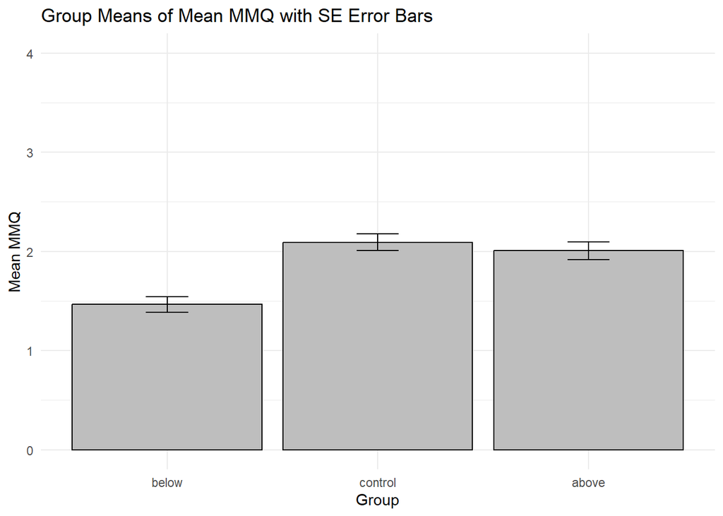

```r
ggplot(group_summary, aes(x = group_all, y = mean_mmq)) +
  geom_col(fill = "gray", color = "black") +
  geom_errorbar(
    aes(ymin = mean_mmq - se_mmq, ymax = mean_mmq + se_mmq),
    width = 0.2,
    color = "black"
  ) +
  labs(
    x = "Group",
    y = "Mean MMQ",
    title = "Group Means of Mean MMQ with SE Error Bars"
  ) +
  theme_minimal() +
  ylim(0, 4)
```

# 4 Information

This script was created and ran in

```
R version 4.5.1
```

## References

Grinschgl, Sandra, Hauke S. Meyerhoff, Stephan Schwan, and Frank Papenmeier. 2021. “From Metacognitive Beliefs to Strategy Selection: Does Fake Performance Feedback Influence Cognitive Offloading?” *Psychological Research* 85 (7): 2654–66. https://doi.org/10.1007/s00426-020-01435-9.